# Working with Packages in R

Paul M. Magwene

September 5, 2016

# Installing Packages in R

Your R Docker container on the OIT managed site comes with many additional packages pre-installed. However, if you’ve installed R and RStudio on your laptop there are a number of useful packages you’ll need to install. Here we show the basic procedure for installing new packages in RStudio.

## Installing Packages in RStudio

Choose the `Packages` tab in the `Files/Plots/Packages/...` pane. The default view in this pane shows you which packages are already installed, and the check boxes next to each package name indicate whether that package has already been loaded into the R interpretter.

To install a new package, click the `Install` button in the `Packages` pane.  
This will bring up a new dialog in which you can type the name of the package you want to install. Let’s install three packages – `ggplot2` (provides powerful plotting capabilities) and `dplyr` (provides powerful data filtering tools) and `tidyr` (provides useful functions for “tidying” messy data sets). Make sure you the `Install dependencies` box is checked in the install dialog.

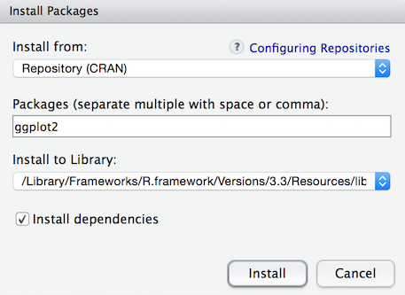

# Loading Packages

The `library` function makes the functions and data defined in a package available for use by the R interpretter.

```r
> library(ggplot2)
```

Once the package is loaded you can use the functions:

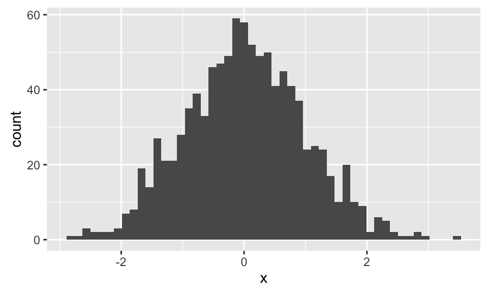

```r
> x <- rnorm(1000) # generate 1000 random draws from normal distn
> qplot(x, geom="histogram", bins=50) # qplot defined in ggplot2
```